# Chen_Ruoyan_A1

## A2: Modeling Case Study

#### DAT-5329 | Introduction to Machine Learning & AI

Ruoyan Chen  
Hult International Business School

In this assignment, I delve into the vital issue of predicting birthweight, an essential indicator of neonatal health. Tasked as a public health consultant, my objective is to apply advanced Computational Analytics and Machine Learning techniques to analyze various factors that influence birthweight. Through rigorous data analysis, I aim to identify significant predictors and their impacts on neonatal outcomes, contributing to the broader field of public health and potentially saving lives. My approach involves employing multiple classification models, including Logistic Regression, Random Forest and Decision Tree, to develop a predictive model that is both accurate and actionable. This work not only enhances our understanding of birthweight determinants but also offers practical insights for healthcare professionals to mitigate risks associated with low birthweight.

## Part I: Imports and Data Check

```python
## importing libraries ##

# for this template
import numpy                 as     np
import pandas                as     pd
import matplotlib.pyplot     as     plt
import sklearn.linear_model
from sklearn.model_selection import train_test_split
from sklearn.linear_model    import LogisticRegression
from sklearn.ensemble        import RandomForestClassifier, GradientBoostingClassifier
from sklearn.metrics         import accuracy_score,f1_score,precision_score,recall_score
from sklearn.tree            import DecisionTreeClassifier
from sklearn.neighbors       import KNeighborsClassifier
from sklearn.model_selection import GridSearchCV
from sklearn.model_selection import cross_val_score
from sklearn.metrics         import confusion_matrix
from sklearn.preprocessing   import StandardScaler
from sklearn.pipeline        import make_pipeline
from sklearn.metrics         import accuracy_score

import warnings
warnings.filterwarnings('ignore')


# setting pandas print options (optional)
pd.set_option('display.max_rows', 500)
pd.set_option('display.max_columns', 500)
pd.set_option('display.width', 1000)
```

```python
## importing data ##

# Reading the first dataset
df_train = pd.read_csv('./datasets/birthweight.csv',
                       index_col='bwt_id')

# Reading the second dataset
df_test = pd.read_csv('./datasets/kaggle_test_data.csv',
                      index_col='bwt_id')
```

```python
# concatenating datasets together for mv analysis and feature engineering
df_train['set'] = 'Not Kaggle'
df_test ['set'] = 'Kaggle'

# concatenating both datasets together for mv and feature engineering
df_full = pd.concat(objs = [df_train, df_test],
                    axis = 0,
                    ignore_index = False)


# checking data
df_full.head(n = 5)
```

| bwt_id | mage | meduc | monpre | npvis | fage | feduc | omaps | fmaps | cigs | drink | male | mwhte | mblck | moth | fwhte | fblck | foth | bwght | set |
| --- | --- | --- | --- | --- | --- | --- | --- | --- | --- | --- | --- | --- | --- | --- | --- | --- | --- | --- | --- |
| bwt_1 | 28 | 12.0 | 2 | 10.0 | 31.0 | 17.0 | 8.0 | 9.0 | 0.0 | 0.0 | 0 | 1 | 0 | 0 | 1 | 0 | 0 | 3317.0 | Not Kaggle |
| bwt_2 | 21 | NaN | 1 | 6.0 | 21.0 | NaN | 8.0 | 9.0 | NaN | NaN | 0 | 1 | 0 | 0 | 1 | 0 | 0 | 1160.0 | Not Kaggle |
| bwt_3 | 27 | 15.0 | 2 | 11.0 | 32.0 | 16.0 | 9.0 | 9.0 | 0.0 | 0.0 | 1 | 1 | 0 | 0 | 1 | 0 | 0 | 4706.0 | Not Kaggle |
| bwt_4 | 33 | 17.0 | 1 | 20.0 | 39.0 | 17.0 | 9.0 | 10.0 | 0.0 | 0.0 | 0 | 0 | 0 | 1 | 0 | 0 | 1 | 3289.0 | Not Kaggle |
| bwt_5 | 30 | 15.0 | 2 | 12.0 | 36.0 | 16.0 | 9.0 | 9.0 | NaN | NaN | 1 | 1 | 0 | 0 | 1 | 0 | 0 | 3490.0 | Not Kaggle |

```python
df_full.shape
```

```
(473, 19)
```

```python
print(df_full["set"].unique())
```

```
['Not Kaggle' 'Kaggle']
```

```python
# checking available features
df_full.columns
```

```
Index(['mage', 'meduc', 'monpre', 'npvis', 'fage', 'feduc', 'omaps', 'fmaps', 'cigs', 'drink', 'male', 'mwhte', 'mblck', 'moth', 'fwhte', 'fblck', 'foth', 'bwght', 'set'], dtype='object')
```

```python
#!##############################!#
#!# set your response variable #!#
#!##############################!#

y_variable = 'low_bwght' # this should be a string
```

## Part II: Data Preparation

### Generating and Displaying Histograms

A histogram shows how the data points are distributed. (e.g., normal distribution, skewness, bimodality, etc.)

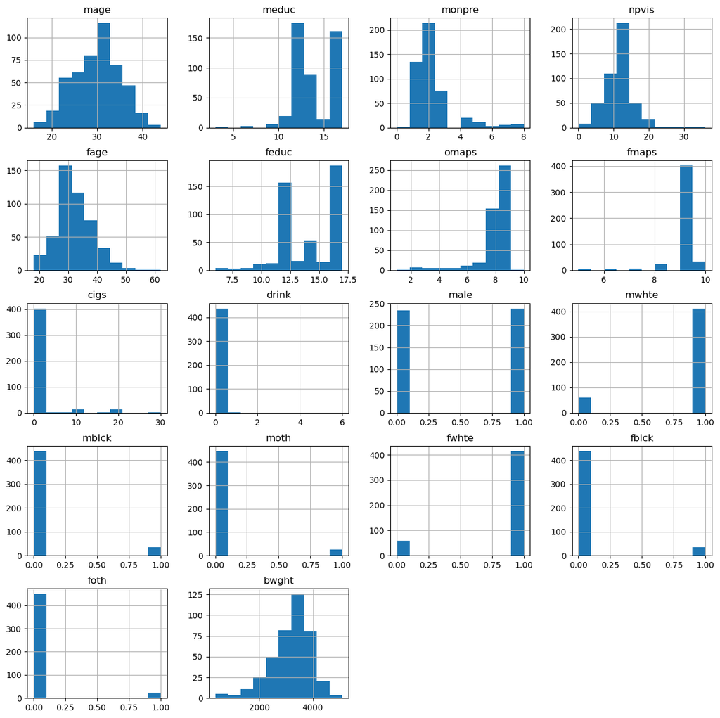

```python
# Develop a histogram to analyze the distribution of the variables
df_full.hist(figsize=(15, 15))
plt.show()
```

#### meduc (Mother's Education)

The histogram indicates that most of the mothers have around 12 to 16 years of education, with spikes at these values, which likely correspond to high school and college graduation levels.

#### npvis (Number of Prenatal Visits)

The distribution shows that the majority of mothers had between 10 to 20 prenatal visits throughout their pregnancy.

#### feduc (Father's Education)

This has a distribution similar to the mother's education, with prominent peaks at around high school and college education levels.

#### omaps & fmaps (One Minute and Five Minute APGAR Score)

The histograms show that the scores mostly cluster around high values, indicating that most babies had good vital signs at 1 and 5 minutes after birth.

#### cigs (Average Cigarettes Per Day)

Most mothers did not smoke during pregnancy, as indicated by the large spike at 0.

#### drink (Average Drinks Per Week)

Similar to smoking, most mothers did not consume alcohol during pregnancy.

#### male (Baby's Gender)

The distribution is almost even, indicating a near equal number of male and female infants.

#### mwhte, mblck, moth (Race of Mother - White, Black, Other)

These histograms show the racial distribution of the mothers, with a higher proportion of white mothers followed by mothers identified as black or other races.

#### fwhte, fblck, foth (Race of Father - White, Black, Other)

The race distribution of the fathers is similar to that of the mothers.

#### bwght (Birth Weight)

The histogram for birth weight is slightly left-skewed, indicating that most babies are within a normal weight range, with a tail towards the lower weights.

### Correlations

Calculate the correlation between different numerical features in a dataset and a specific target variable, in this case, 'bwght' (birth weight)

```python
# Select only numeric columns for correlation calculation
numeric_df = df_full.select_dtypes(include=[np.number])

# Calculate the correlation with 'bwght'
correlations = numeric_df.corr()['bwght']

# Get the 10 features with the highest absolute correlation
_10_features = correlations.abs().nlargest(10).index

# Get the correlation values for these features
_10_corr_values = correlations[_10_features]
```

```python
print(_10_corr_values)
```

```
bwght     1.000000
omaps     0.405356
fmaps     0.382021
npvis     0.180625
fage      0.138822
foth     -0.074563
male      0.061118
feduc     0.060550
monpre    0.055095
mage      0.054616
Name: bwght, dtype: float64
```

#### Analysis Questions 1

Are there any strong positive or strong negative linear (Pearson) correlations with birthweight? Answer this question based on the original, continuous form of birthweight.

### Missing Value Analysis and Imputation

Mean imputation can be used when the distribution of the data is normal, and the missing values are random.  
Median imputation is appropriate when the distribution of the data is skewed.  
Mode imputation is used when dealing with categorical data, where the mode represents the most common category.

```python
## Missing Value Imputation ##
df_full.isna().sum()
```

```
mage       0
meduc      6
monpre     0
npvis     21
fage       1
feduc     10
omaps      2
fmaps      2
cigs      33
drink     32
male       0
mwhte      0
mblck      0
moth       0
fwhte      0
fblck      0
foth       0
bwght     64
set        0
dtype: int64
```

#### npvis & fage

right-skewed, imputaion with median

#### feduc, omaps, fmaps & bwght

left-skewed, imputaion with median

#### cigs & drink

```python
# imputation of missing values using the mean
df_full[['meduc']] = df_full[['meduc']].fillna(df_full.median(numeric_only=True))

# imputation of missing values using the median
df_full[['npvis', 'fage', 'feduc', 'omaps', 'fmaps', 'bwght']] = df_full[['npvis', 'fage', 'feduc', 'omaps', 'fmaps', 'bwght']].fillna(df_full.median(numeric_only=True))

# imputation of missing values using the mode
df_full[['cigs', 'drink']] = df_full[['cigs', 'drink']].fillna(df_full.median(numeric_only=True))
```

```python
df_full.isna().sum()
```

```
mage      0
meduc     0
monpre    0
npvis     0
fage      0
feduc     0
omaps     0
fmaps     0
cigs      0
drink     0
male      0
mwhte     0
mblck     0
moth      0
fwhte     0
fblck     0
foth      0
bwght     0
set       0
dtype: int64
```

### Transformations

```python
# Transformations
df_full['low_bwght'] = np.where(df_full['bwght'] < 2500, 0, 1)
```

#### Analysis Questions 2

Is there an official threshold that signifies when birthweight gets more dangerous? In other words, is there a cutoff point between a healthy birthweight and a non-healthy birthweight? Provide credible sources as necessary.

#### Answer

Yes, there is an official threshold that signifies when birthweight gets more dangerous.

A birth weight less than 2,500 grams is generally considered low and is used as a threshold to identify newborns who may be at higher risk for certain health complications. Low birth weight (low_bwght) infants might be at increased risk for infections, developmental delays, and other medical challenges.

The credible source is Committee to Study the Prevention of Low Birthweight; Division of Health Promotion and Disease Prevention; Institute of Medicine. Preventing Low Birthweight. Washington (DC): National Academies Press (US); 1985 Jan 1. 1, The Significance of Low Birthweight. Available from: https://www.ncbi.nlm.nih.gov/books/NBK214473/

```python
## Correlation after transformation ##

# Select only numeric columns for correlation calculation
numeric_df = df_full.select_dtypes(include=[np.number])

# Calculate the correlation with low birth weight
correlations = numeric_df.corr()['low_bwght']

# Get the 10 features with the highest absolute correlation
_10_features = correlations.abs().nlargest(10).index

# Get the correlation values for these features
_10_corr_values = correlations.loc[_10_features]
```

```python
print(_10_corr_values)
```

```
low_bwght    1.000000
bwght        0.772281
omaps        0.364681
fmaps        0.295802
npvis        0.119877
fage         0.079275
mwhte       -0.055817
monpre       0.052656
male         0.049890
cigs        -0.049526
Name: low_bwght, dtype: float64
```

#### Analysis Questions 3

After transforming birthweight (bwght) using this threshold, did correlations and/or phi coefficients improve? Why or why not?

#### Answer

After missing Value imputation and transforming bwght using this threshold into new feature (low_bwght), the correlation coefficients decrease (lower than before). This may because when binarize the variable, all the detailed variation within the groups (below and above 2500 grams) is lost, and only the difference between these two groups is considered. The transformed data become categorical data (low weight=0, healthy weight=1), so that it is centred between 0 and 1, compared to the previous continuous number.

### Feature Engineering

#### Average Age of Parents

```python
df_full['parents_avg_age'] = (df_full['mage'] + df_full['fage']) / 2
```

#### Total Parental Education

```python
df_full['total_parent_educ'] = df_full['meduc'] + df_full['feduc']
```

#### Healthy Lifestyle Score

```python
df_full['healthy_lifestyle_score'] = (df_full['npvis'] - df_full['cigs'] - df_full['drink']).clip(lower=0)
```

#### Health Index

```python
df_full['health_index'] = (df_full['meduc'] + df_full['npvis']) - (df_full['cigs'] + df_full['drink'])
```

#### Interaction terms

```python
# mother's age * father's age
df_full['age_interaction'] = df_full['mage'] * df_full['fage']

# mother's education * total number of prenatal visits
df_full['education_prenatal_interaction'] = df_full['meduc'] * df_full['npvis']
```

```python
numeric_df = df_full.select_dtypes(include=[np.number])
correlation_matrix = numeric_df.corr()
birth_weight_correlations = correlation_matrix['low_bwght']
high_corr_features = birth_weight_correlations.abs().nlargest(20)
```

```python
print(high_corr_features)
```

```
low_bwght                         1.000000
bwght                             0.772281
omaps                             0.364681
fmaps                             0.295802
npvis                             0.119877
healthy_lifestyle_score           0.110563
health_index                      0.090654
education_prenatal_interaction    0.090248
fage                              0.079275
parents_avg_age                   0.064167
age_interaction                   0.060591
mwhte                             0.055817
monpre                            0.052656
male                              0.049890
cigs                              0.049526
fblck                             0.041359
mblck                             0.041359
mage                              0.035107
moth                              0.034580
fwhte                             0.031117
Name: low_bwght, dtype: float64
```

### Standardization

```python
## Standardization ##
#SCALING


scaled_features=['omaps', 'fmaps', 'npvis',
                 'healthy_lifestyle_score', 'health_index',
                 'education_prenatal_interaction', 'fage',
                 'parents_avg_age', 'age_interaction', 'mwhte',
                 'monpre', 'male', 'cigs', 'fblck', 'mblck',
                 'mage', 'moth', 'fwhte']

scaler = StandardScaler()

df_full[scaled_features] = scaler.fit_transform(df_full[scaled_features])

df_full.head()
```

| bwt_id | mage | meduc | monpre | npvis | fage | feduc | omaps | fmaps | cigs | drink | male | mwhte | mblck | moth | fwhte | fblck | foth | bwght | set | low_bwght | parents_avg_age | total_parent_educ | healthy_lifestyle_score | health_index | age_interaction | education_prenatal_interaction |
| --- | --- | --- | --- | --- | --- | --- | --- | --- | --- | --- | --- | --- | --- | --- | --- | --- | --- | --- | --- | --- | --- | --- | --- | --- | --- | --- |
| bwt_1 | -0.349855 | 12.0 | -0.154337 | -0.405911 | -0.192141 | 17.0 | -0.167271 | 0.084703 | -0.268141 | 0.0 | -1.010627 | 0.384783 | -0.282681 | -0.241175 | 0.373844 | -0.282681 | 0 | 3317.0 | Not Kaggle | 1 | -0.286528 | 29.0 | -0.191417 | -0.313921 | -0.348429 | -0.666185 |
| bwt_2 | -1.722333 | 13.0 | -0.906928 | -1.449367 | -1.835593 | 14.0 | -0.167271 | 0.084703 | -0.268141 | 0.0 | -1.010627 | 0.384783 | -0.282681 | -0.241175 | 0.373844 | -0.282681 | 0 | 1160.0 | Not Kaggle | 0 | -1.935759 | 27.0 | -1.049618 | -0.758486 | -1.679858 | -1.391319 |
| bwt_3 | -0.545924 | 15.0 | -0.154337 | -0.145047 | -0.027796 | 16.0 | 0.565315 | 0.084703 | -0.268141 | 0.0 | 0.989484 | 0.384783 | -0.282681 | -0.241175 | 0.373844 | -0.282681 | 0 | 4706.0 | Not Kaggle | 1 | -0.286528 | 31.0 | 0.023133 | 0.278832 | -0.360902 | 0.110745 |
| bwt_4 | 0.630486 | 17.0 | -0.906928 | 2.202730 | 1.122620 | 17.0 | 0.565315 | 1.826643 | -0.268141 | 0.0 | -1.010627 | -2.598865 | -0.282681 | 4.146361 | -2.674915 | -0.282681 | 1 | 3289.0 | Not Kaggle | 1 | 0.974648 | 34.0 | 1.954086 | 1.908904 | 0.958054 | 3.132137 |
| bwt_5 | 0.042281 | 15.0 | -0.154337 | 0.115817 | 0.629584 | 16.0 | 0.565315 | 0.084703 | -0.268141 | 0.0 | 0.989484 | 0.384783 | -0.282681 | -0.241175 | 0.373844 | -0.282681 | 0 | 3490.0 | Not Kaggle | 1 | 0.392566 | 31.0 | 0.237684 | 0.427021 | 0.312608 | 0.369721 |

## Part III: Data Partitioning

This is a very important step for your submission on Kaggle. Make sure to complete your data preparationbefore moving forward.

### Separating the Kaggle Data

```python
# dataset for kaggle
kaggle_data = df_full[ df_full['set'] == 'Kaggle' ].copy()


# dataset for model building
df = df_full[ df_full['set'] == 'Not Kaggle' ].copy()


# dropping set identifier (kaggle)
kaggle_data.drop(labels = 'set',
                 axis = 1,
                 inplace = True)


# dropping set identifier (model building)
df.drop(labels = 'set',
        axis = 1,
        inplace = True)
```

### Train-Test Split

Note that the following code will remove non-numeric features, keeping only integer and float data types. It will also remove any observations that contain missing values. This is to prevent errors in the model building process.

```python
#!###########################!#
#!# choose your x-variables #!#
#!###########################!#

x_features = ['omaps', 'fmaps', 'npvis',
              'healthy_lifestyle_score', 'health_index',
              'education_prenatal_interaction', 'fage',
              'parents_avg_age', 'age_interaction', 'mwhte',
              'monpre', 'male', 'cigs', 'fblck', 'mblck',
              'mage', 'moth', 'fwhte']
```

```python
# prepping data for train-test split
y_data = df[y_variable]


# removing non-numeric columns and missing values
x_data = df[x_features].copy().select_dtypes(include=[int, float]).dropna(axis = 1)


# storing remaining x_features after the step above
x_features = list(x_data.columns)


# train-test split (to validate the model)
x_train, x_test, y_train, y_test = train_test_split(x_data,
                                                    y_data,
                                                    test_size    = 0.25,
                                                    random_state = 702 )
```

## Part III: Candidate Modeling

Develop your candidate models below.

```python
# Develop and evaluate models
models = {'Logistic Regression': LogisticRegression(),
          'Random Forest Classifier': RandomForestClassifier(random_state=2),
          'Decision Tree Classification': DecisionTreeClassifier()}
```

```python
for model_name, model in models.items():
    # FITTING to the training data
    model.fit(x_train, y_train)
    # PREDICTING on new data
    model_pred = model.predict(x_test)

    # SCORING the results
    model_train_score = model.score(x_train, y_train).round(4)
    model_test_score  = model.score(x_test, y_test).round(4)
    model_gap         = abs(model_train_score - model_test_score).round(4)

    # dynamically printing results
    model_summary =  f"""\
    Model Name:     {model_name}
    Train_Score:    {model_train_score}
    Test_Score:     {model_test_score}
    Train-Test Gap: {model_gap}
    """

    print(model_summary)
```

```
    Model Name:     Logistic Regression
    Train_Score:    0.8431
    Test_Score:     0.8252
    Train-Test Gap: 0.0179

    Model Name:     Random Forest Classifier
    Train_Score:    1.0
    Test_Score:     0.8155
    Train-Test Gap: 0.1845

    Model Name:     Decision Tree Classification
    Train_Score:    1.0
    Test_Score:     0.7864
    Train-Test Gap: 0.2136
```

```python
for model_name, model in models.items():
    # Create a pipeline with standardization and the model to ensure all features are on the same scale
    pipeline = make_pipeline(StandardScaler(), model)

    # FITTING to the training data
    pipeline.fit(x_train, y_train)

    # Access the trained model directly as the last step of the pipeline
    trained_model = pipeline.steps[-1][1]  # steps is a list of tuples, -1 accesses the last step, 1 accesses the model

    # Feature importances or coefficients
    if hasattr(trained_model, 'feature_importances_'):
        importances = trained_model.feature_importances_
    elif hasattr(trained_model, 'coef_'):
        importances = np.abs(trained_model.coef_[0])

    # Get the top two features
    top_two_indices = np.argsort(importances)[-2:]
    top_two_features = [x_train.columns[i] for i in top_two_indices]

    # Print the top two features
    print(f"{model_name}: Top two features - {top_two_features}")
```

```
Logistic Regression: Top two features - ['fmaps', 'fwhte']
Random Forest Classifier: Top two features - ['fage', 'age_interaction']
Decision Tree Classification: Top two features - ['fmaps', 'fage']
```

#### Analysis Questions 4

Which two features in your machine learning model had the largest impact on birthweight? Present one actionable insight for each of these.

#### Logistic Regression - Top Features: fmaps and fwhte

Actionable Insight for fmaps (Five-Minute APGAR Score): APGAR scores are used to quickly summarize the health of newborns. A low score on fmaps could indicate distress or health issues. Healthcare providers can use this information to immediately intervene, providing necessary care to improve the baby's health outcome. Regular training for medical staff on efficiently assessing and acting upon APGAR scores can enhance neonatal care.

Actionable Insight for fwhte (Father's Race: White): If race is showing as a significant factor, it may reflect underlying socioeconomic or environmental factors that correlate with birth outcomes. Public health strategies can be designed to address these disparities by ensuring equitable access to prenatal care and targeting health education programs in communities with identified needs.

#### Random Forest Classifier - Top Features: fage and age_interaction

Actionable Insight for fage (Father's Age): Older paternal age might be associated with increased risks for certain conditions in offspring. This insight can guide public health messaging to encourage earlier family planning or heightened prenatal screening and monitoring for older fathers.

Actionable Insight for age_interaction (Interaction term involving age): If an interaction involving age is significant, it suggests that the effect of age on birthweight is not uniform across the dataset. Identifying the specific nature of this interaction (e.g., between maternal and paternal age, or age and a health behavior) can lead to targeted interventions that address the nuanced impact of age-related factors on birth outcomes.

Actionable Insight for fmaps (Five-Minute APGAR Score): Similar to the insight from Logistic Regression, emphasizing the importance of immediate postnatal care and interventions based on APGAR scores can improve neonatal health outcomes. Developing protocols to act on APGAR scores promptly can save lives and reduce the incidence of complications.

```python
for model_name, model in models.items():
    # Predicting on the test set
    y_pred = model.predict(x_test)

    # Calculating the accuracy
    accuracy = accuracy_score(y_test, y_pred)

    # Printing the model name and its accuracy
    print(f"{model_name} Accuracy: {accuracy:.4f}")
```

```
Logistic Regression Accuracy: 0.8252
Random Forest Classifier Accuracy: 0.8058
Decision Tree Classification Accuracy: 0.7573
```

### Residual Analysis

```python
## Residual Analysis ##

# organizing residuals
model_residuals = {"True"            : y_test,
                   "Predicted"       : model_pred
                  }


# converting residuals into df
model_resid_df = pd.DataFrame(data = model_residuals)


# checking results
model_resid_df.head(n = 5)
```

| bwt_id | True | Predicted |
| --- | --- | --- |
| bwt_104 | 0 | 1 |
| bwt_435 | 1 | 1 |
| bwt_81 | 1 | 0 |
| bwt_37 | 1 | 1 |
| bwt_100 | 0 | 0 |

### Hyperparameter Tuning

```python
## Hyperparameter Tuning ##
clf = RandomForestClassifier(max_depth=10, random_state=0)
clf.fit(x_train, y_train)
y_pred = clf.predict(x_test)
print("Without CV: ",accuracy_score(y_test,y_pred))
scores = cross_val_score(clf, x_train, y_train, cv=10)

print("With CV: ",scores.mean())
print("Precision Score: ", precision_score(y_test, y_pred,average='macro'))
print("Recall Score: ", recall_score(y_test, y_pred,average='macro'))
print("F1 Score: ", f1_score(y_test, y_pred,average='macro'))
```

```
Without CV:  0.8252427184466019
With CV:  0.816989247311828
Precision Score:  0.6763157894736842
Recall Score:  0.5875816993464051
F1 Score:  0.6038461538461538
```

```python
clf = sklearn.linear_model.LogisticRegression(random_state=42)
clf.fit(x_train, y_train)
y_pred = clf.predict(x_test)
print("Without CV: ",accuracy_score(y_test,y_pred))
scores = cross_val_score(clf, x_train, y_train, cv=10)

print("With CV: ",scores.mean())
print("Precision Score: ", precision_score(y_test, y_pred,average='macro'))
print("Recall Score: ", recall_score(y_test, y_pred,average='macro'))
print("F1 Score: ", f1_score(y_test, y_pred,average='macro'))
```

```
Without CV:  0.8252427184466019
With CV:  0.8302150537634407
Precision Score:  0.6726804123711341
Recall Score:  0.5656862745098039
F1 Score:  0.5755494505494505
```

```python
clf = sklearn.tree.DecisionTreeClassifier(random_state=0)
clf.fit(x_train, y_train)
y_pred = clf.predict(x_test)
print("Without CV: ",accuracy_score(y_test,y_pred))
scores = cross_val_score(clf, x_train, y_train, cv=10)

print("With CV: ",scores.mean())
print("Precision Score: ", precision_score(y_test, y_pred,average='macro'))
print("Recall Score: ", recall_score(y_test, y_pred,average='macro'))
print("F1 Score: ", f1_score(y_test, y_pred,average='macro'))
```

```
Without CV:  0.7961165048543689
With CV:  0.7095698924731183
Precision Score:  0.6419288645690835
Recall Score:  0.6356209150326797
F1 Score:  0.6385964912280702
```

```python
ytrue=model_resid_df['True']
ypred=model_resid_df['Predicted']
```

```python
from sklearn.metrics import confusion_matrix
confusion_matrix(ytrue,ypred)
```

```
array([[ 7, 11],
       [11, 74]])
```

#### Analysis Questions 5

Present your final model's confusion matrix and explain what each error means (false positives and false negatives). Furthermore, explain which error is being controlled for given the cohort's focus on correctly predicting low birthweight, as well as why this error is more important to control than the other error.

#### Answer

The confusion matrix:

|  | Predicted No | Predicted Yes |
| --- | --- | --- |
| Actual No | TN: 7 | FP: 11 |
| Actual Yes | FN: 11 | TP: 74 |

Where:

- **TN** is True Negative
- **FP** is False Positive
- **FN** is False Negative
- **TP** is True Positive

## Part IV: Preparing Submission File for Kaggle

The code below will store the predicted values for each of the models above.

```python
# x-data
x_data_kaggle = kaggle_data[x_features].copy()


# y-data
y_data_kaggle = kaggle_data[y_variable]


# Fitting model from above to the Kaggle test data
kaggle_predictions = model.predict(x_data_kaggle)
```

### Creating the Kaggle File

```python
## Kaggle Submission File ##

# organizing predictions
model_predictions = {"low_bwght" : kaggle_predictions}


# converting predictions into df
model_pred_df = pd.DataFrame(data  = model_predictions,
                             index = df_test.index)
```

```python
#!######################!#
#!# name the .csv file #!#
#!######################!#

# name your model
model_pred_df.to_csv(path_or_buf = "./model_output/Chen_Ruoyan_A2.csv",
                     index       = True,
                     index_label = 'bwt_id')
```